# Расчёт параметров регулирующего клапана

В данной статье приведён пример использования класса `ControlValve` (скачать) для расчёта характеристик регулирующего клапана (РК), в котором (в том числе) реализованы расчётные формулы, приведённые в [1], [2], [3].

РК характеризуется значением условной (максимальной) пропускной способности $K_{Vs}$, видом пропускной характеристики и относительной начальной пропускной способностью $\Phi_0$.

В данной методике рассматриваются следующие виды пропускной характеристики:

1. Линейная $Q = K_{Vs}(\Phi_0 + (1-\Phi_0) \bar{h})$
2. Равнопроцентная $Q = K_{Vs} \Phi_0^{1-\bar{h}}$ или $Q = K_{Vs} \Phi_0 e^{n\bar{h}}$; $\Phi_0 = 1/e^n$; $n = \ln{(1/\Phi_0)}$
3. Параболическая $Q = K_{Vs} (\Phi_0 + (1-\Phi_0)\bar{h}^2)$

$Q$ - объёмный расход, $м^3/ч$.

$K_V(\bar{h})$ - пропускная способность, $м^3/ч$ - значение, равное расходу жидкости плотностью 1000 $кг/м^3$, протекающей через клапан при положении штока $\bar{h}$ и перепаде давления на нём 0,1 МПа (1,0 $кгс/см^2$).

$K_{Vs}$ - условная (максимальная) пропускная способность, $м^3/ч$ (при $\bar{h} = 1$).

$\bar{h}$ - относительное положение штока РК, $\bar{h} = [0; 1]$.

$\Phi_0 \equiv \bar{K}_{V0} = K_{V0}/K_{Vs}$ - относительная начальная пропускная способность.

$K_{V0}$ - начальная пропускная способность, $м^3/ч$ - Пропускная способность, задаваемая для построения пропускной характеристики при $\bar{h} = 0$.

$K_{Vmin}$ - минимальная пропускная способность, $м^3/ч$ - Наименьшая пропускная способность, при которой сохраняется пропускная характеристика в допускаемых пределах.

В данной методике принято $K_{V0} \equiv K_{Vmin}$. В этом случае $\Phi_0$ является обратной величиной диапазона регулирования $Д=K_{Vs}/K_{Vmin}$.

```python
from controlvalve import ControlValve  # Загрузка класса ControlValve
```

```python
help(ControlValve.__init__)  # Описание входных параметров, передаваемых в конструктор класса ControlValve
```

```
Help on function __init__ in module controlvalve:

__init__(self, Kv=1.0, fc_type=0, F0=0.0, h=1.0, density=998.2)
    Kv: требуемая пропускная способность РК (по умолчанию Kv=1) при заданном положении штока h
    fc_type: flow characteristic type - вид пропускной характеристики 0 - линейная (по умолчанию),
    1 - равнопроцентная, 2 - параболическая
    F0: относительная начальная пропускная способность при положении штока РК h = 0 (F0 = Kv0/Kvs).
        По умолчанию F0=0.
    h: относительное положения штока РК (0;1], при котором значение пропускной способности равно Kv.
       По умолчанию h=1.
    density: плотность среды, кг/м3. По умолчанию - плотность воды при температуре 20 С.
```

```python
Kvs = 200.; F0 = 1/50; h = 1; density = 998.2;
# Создаём объект класса ControlValve
cv = ControlValve(Kvs, 1, F0, h, density)  # выберем равнопроцентную пропускную характеристику
```

```python
cv.set_h(0.4)  # зададим относительное положение штока (при создании объекта задаётся h = 1)
# При вызове метода set_h вычисляются Kv (пропускная способность) и R(гидравлическое сопротивление),
# значения которых можно узнать с помощью методов get_Kv() и get_R() соответственно.
print(f"Kv={cv.get_Kv()} м3/ч; R={cv.get_R()} Па*ч^2/м^6" )
```

```
Kv=19.12704999580074 м3/ч; R=272.8485055525451 Па*ч^2/м^6
```

```python
# Метод h_from_Kv - определение значения h по значению Kv
help(cv.h_from_Kv)
```

```
Help on method h_from_Kv in module controlvalve:

h_from_Kv(Kv) method of controlvalve.ControlValve instance
    Определение положения штока h = [0; 1] при котором РК будет иметь заданный Kv
    Kv: пропускная способность, м3/ч
```

```python
cv.h_from_Kv(Kvs*F0), cv.h_from_Kv(19.12704999580074), cv.h_from_Kv(Kvs)
```

```
(0.0, 0.39999999999999997, 1.0)
```

```python
help(cv.dp_from_Q)
```

```
Help on method dp_from_Q in module controlvalve:

dp_from_Q(Q) method of controlvalve.ControlValve instance
    Возвращает значение перепада давления на РК, Па
    Q: Расход через РК, м3/ч
```

```python
cv.dp_from_Q(Kvs)
```

```
10913940.222101804
```

```python
help(cv.Q_from_dp)
```

```
Help on method Q_from_dp in module controlvalve:

Q_from_dp(dp) method of controlvalve.ControlValve instance
    Определение объёмного расхода (м3/ч) по перепаду давления на РК (Па)
    dp: Падение давления на РК, Па
```

```python
cv.Q_from_dp(10913940.222101804)
```

```
200.0
```

## Построение расходной и пропускной характеристик

Движение рабочей среды по участку трубопровода возможно только при наличии разницы давления в начале и в конце рассматриваемого участка. Отношение перепада давления на РК к перепаду давления на регулируемом участке (без учёта нивелирной составляющей) называется авторитетом РК.

$m = \Delta p_{рк}/\Delta p$

$m$ - авторитет РК, $\Delta p_{рк}$ - перепад давления на РК, $\Delta p$ - перепад давления (без учёта нивелирной составляющей) на регулируемом участке с учётом потерь давления в РК.

```python
#Получить данные для построения расходную и пропускную характеристик можно с помощью метода get_char
help(cv.get_char)
```

```
Help on method get_char in module controlvalve:

get_char(Q, m=1, h=1.0, n=51) method of controlvalve.ControlValve instance
    Расчёт данных для построения расходной характеристики
    При построении расходной характеристики предполагается, что перепад давления на регулируемом участке не
    зависит от расхода
    Q: номинальный расход (м3/ч) при заданных m и h
    m: авторитет РК при номинальном расходе (по умолчанию m=1)
    h: положение штока РК (по умолчанию h=1) при котором РК имеет авторитет m и через него проходит расход Q
    n: количество точек представления характеристики (по умолчанию 51)
```

```python
Q_nom = 200  # номинальный расход, м3/ч
m = 0.1  # авторитет РК с h=1 с заданным Kvs при номинальном расходе
hs, Qs, ms = cv.get_char(Q_nom, m)
qs = Qs / Q_nom  # относительный расход, чтобы отобразить Q и m на одном графике
```

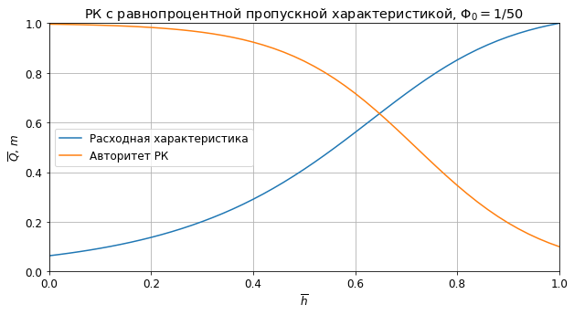

```python
import matplotlib.pyplot as plt
plt.rcParams['font.size'] = 12.0
fig, ax = plt.subplots(figsize = (10,5))
ax.set_title("РК с равнопроцентной пропускной характеристикой, $\Phi_0=1/50$")
ax.grid(); ax.set_xlim(0,1); ax.set_ylim(0,1)
ax.plot(hs, qs, label = "Расходная характеристика")
ax.plot(hs, ms, label = "Авторитет РК")
ax.set_xlabel('$\overline{h}$'); ax.set_ylabel('$\overline{Q}$, $m$')
ax.legend();
```

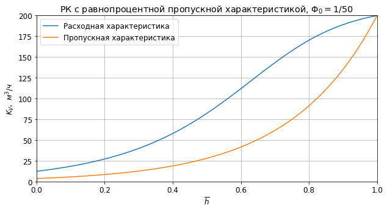

```python
# Пропускная характеристика - это частный случай расходной характеритики при авторитете РК m=1 и Q = Kvs
hs, Qs_1, _ = cv.get_char(Kvs, 1)
fig, ax = plt.subplots(figsize = (10,5))
ax.set_title("РК с равнопроцентной пропускной характеристикой, $\Phi_0=1/50$")
ax.grid(); ax.set_xlim(0,1); ax.set_ylim(0,Kvs)
ax.plot(hs, Qs, label = "Расходная характеристика")
ax.plot(hs, Qs_1, label = "Пропускная характеристика")
ax.set_xlabel('$\overline{h}$'); ax.set_ylabel('$K_V,\ м^3/ч$');
ax.legend();
```

## Вспомогательные (статические) методы

Предположим, нам нужно подобрать РК для регулирования расхода рабочей среды в линии.

```python
Q = 100  # номинальный расход рабочей среды через рассматриваемый участок, м3/ч
dp = 1e5 # потери давления на рассматриваем участке (Па) при расходе Q без учёта
         # нивелирной составляющей и падении давления на РК
```

Примем следующие параметры РК:

1. диапазон регулирования 50 ($\Phi_0 = 0.02$);
2. расход Q через РК должен наблюдаться при положении штока РК $\bar{h_0} = 0.9$;
3. авторитет РК при относительном положении штока $\bar{h_0} = 0.9$ равен $m = 0.1$.

```python
F0 = 1 /50; h0 = 0.9; m = 0.1
```

С помощью статического метода `Kv_from_m_dp_Q` найдём значение $K_V$, при котором при заданных условиях расход через РК будет равен $Q$ при авторитете РК $m$.

```python
help(ControlValve.Kv_from_m_dp_Q)
```

```
Help on function Kv_from_m_dp_Q in module controlvalve:

Kv_from_m_dp_Q(m, dp, Q, density=998.2)
    Расчёт Kv для заданных значений авторитета РК, перепада давления на регулируемом участке и объёмного расхода
    m: авторитет клапана (0; 1], m = dp_cv/(dp + dp_cv), dp_cv - перепад давления на РК, Па
    dp: перепад давления на регулируемом участке без учёта нивелирной состовляющей и потери давления в РК , Па
    Q: расход через регулируемый участок, м3/ч
    density: плотность среды, кг/м3. По умолчанию - плотность воды при температуре 20 С
```

```python
Kv = ControlValve.Kv_from_m_dp_Q(m, dp, Q)
Kv  # м3/ч
```

```
299.72987839052684
```

Если бы $\bar{h}_0 = 1$, то на этом можно было бы и остановиться, выбрав РК с $K_{Vs}$ выше найденного $K_{V}$.

Но в нашем случае условия заданы для $\bar{h}_0 = 0.9$. В этом случае следует использовать статический метод `Kvs_from_m_dp_Q_h`.

Найдём требуемое значение $K_{Vs}$ РК для заданных условий для всех трёх видов пропускной характеристики.

```python
help(ControlValve.Kvs_from_m_dp_Q_h)
```

```
Help on function Kvs_from_m_dp_Q_h in module controlvalve:

Kvs_from_m_dp_Q_h(m, dp, Q, h=1.0, fc_type=0, F0=0.0, density=998.2)
    Вычисление Kvs для заданных значений авторитета РК, перепада давления на регулируемом участке, объёмного
    расхода и положения штока
    m: авторитет клапана (0; 1], m = dp_cv/dp, dp_cv - перепад давления на РК, Па
    dp: перепад давления на регулируемом участке без учёта нивелирной составляющей и потери давления в РК , Па
    Q: расход через РК, м3/ч
    h: относительное положение штока РК (0;1]
    fc_type: вид пропускной характеристики 0 - линейная (по умолчанию), 1 - равнопроцентная, 2 - параболическая
    F0: относительная начальная пропускной способность, F0 = Kv0 / Kvs
    density: плотность среды, кг/м3. По умолчанию - плотность воды при температуре 20 С
```

```python
Kvss = []
Kvss.append(ControlValve.Kvs_from_m_dp_Q_h(m, dp, Q, h0, 0, F0))
Kvss.append(ControlValve.Kvs_from_m_dp_Q_h(m, dp, Q, h0, 1, F0))
Kvss.append(ControlValve.Kvs_from_m_dp_Q_h(m, dp, Q, h0, 2, F0))
Kvss
```

```
[332.29476539969716, 443.22784659566736, 368.309017437364]
```

Из результатов расчёта видно, что для достижения заданного условия - расход $Q$ и авторитет РК $m = 0.1$ при $\bar{h} = \bar{h}_0$, РК с различными видами пропускных характеристик должны иметь различные значения $K_{Vs}$.

```python
# Создаём объекты класса ControlValve с различными пропускными характеристиками
# расходная характеристика которых проходит через точку (h = 0,9; Q = 100)
cvs = [ControlValve(Kv, 0, F0, h0), ControlValve(Kv, 1, F0, h0), ControlValve(Kv, 2, F0, h0)]
titles = ["Линейная", "Равнопроцентная", "Параболическая"]
```

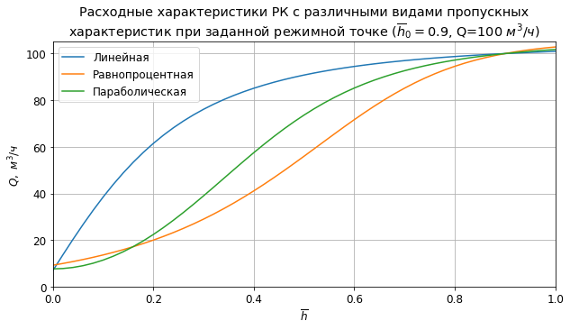

```python
import matplotlib.pyplot as plt
plt.rcParams['font.size'] = 12.0
fig, ax = plt.subplots(figsize = (10,5))
ax.set_title("Расходные характеристики РК с различными видами пропускных\nхарактеристик"
            " при заданной режимной точке ($\overline{h}_0 =$" + f"{h0}" + f", Q={Q}" + " $м^3/ч$)")
ax.grid(); ax.set_xlim(0,1); ax.set_ylim(0,105 )
for i, cv in enumerate(cvs):
    hs, Qs, _ = cv.get_char(Q, m, h0)
    ax.plot(hs, Qs, label = titles[i])
ax.set_xlabel('$\overline{h}$'); ax.set_ylabel('$Q,\ м^3/ч$')
ax.legend();
```

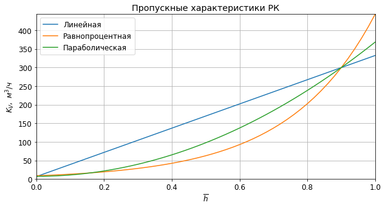

```python
import matplotlib.pyplot as plt
plt.rcParams['font.size'] = 12.0
fig, ax = plt.subplots(figsize = (10,5))
ax.set_title("Пропускные характеристики РК")
ax.grid(); ax.set_xlim(0,1); ax.set_ylim(0,max(Kvss))
for i, cv in enumerate(cvs):
    hs, Qs, _ = cv.get_char(Kv, 1, h0)
    ax.plot(hs, Qs, label = titles[i])
ax.set_xlabel('$\overline{h}$'); ax.set_ylabel('$K_V,\ м^3/ч$')
ax.legend();
```

```python
#Kvs РК с линейной, равнопроцентной и параболической пропускными характеристиками
cvs[0].Kvs, cvs[1].Kvs, cvs[2].Kvs
```

```
(332.29476539969716, 443.22784659566736, 368.309017437364)
```

```python
# Полный перечень методов класса ControlValve
help(ControlValve)
```

```
Help on class ControlValve in module controlvalve:

class ControlValve(builtins.object)
 |  ControlValve(Kv=1.0, fc_type=0, F0=0.0, h=1.0, density=998.2)
 |  Объект 'Регулирующий клапан (РК)'
 |  РК характеризуется значением Kvs, видом пропускной характеристики и относительной начальной пропускной способностью
 |  Пропускная характеристика может быть:
 |  1. Линейной Q = Kvs * (F0 + (1-F0)*h)
 |  2. Равнопроцентной Q = Kvs * F0 * exp(n*h); F0 = 1/exp(n); n = ln(1/F0); Q = Kvs* F0^(1-h)
 |  3. Параболической Q = Kvs * (F0 + (1-F0)*h*h)
 |  Q - расход, м3/ч
 |  Kv - пропускная способность, м3/ч -  значение, равное расходу жидкости плотностью 1000 кг/м3, протекающей
 |       через клапан при положении штока h и перепаде давления на нем 0,1 МПа (1,0 кгс/см2).
 |  h - относительное положение штока,  h = [0; 1]
 |  Kvs - условная (максимальная) пропускная способность, м3/ч (при h = 1)
 |  F0 = Kv0/Kvs - относительная начальная пропускная способность
 |  Kv0 - начальная пропускная способность, м3/ч - Пропускная способность, задаваемая для построения пропускной
 |        характеристики при h = 0
 |  Kvmin - минимальная пропускная способность, м3/ч - Наименьшая пропускная способность,
 |          при которой сохраняется пропускная характеристика в допускаемых пределах.
 |  В данном расчёте принято Kv0 эквивалентно Kvmin
 |  См. так же:
 |  ГОСТ 12893-2005 Клапаны регулирующие односедельные, двухседельные и клеточные. Общие технические условия
 |  Methods defined here:
 |  Q_from_dp(self, dp)
 |      Определение объёмного расхода (м3/ч) по перепаду давления на РК (Па)
 |      dp: Падение давления на РК, Па
 |  __init__(self, Kv=1.0, fc_type=0, F0=0.0, h=1.0, density=998.2)
 |      Kv: требуемая пропускная способность РК (по умолчанию Kv=1) при заданном положении штока h
 |      fc_type: flow characteristic type - вид пропускной характеристики 0 - линейная (по умолчанию),
 |      1 - равнопроцентная, 2 - параболическая
 |      F0: относительная начальная пропускная способность при положении штока РК h = 0 (F0 = Kv0/Kvs).
 |          По умолчанию F0=0.
 |      h: относительное положения штока РК (0;1], при котором значение пропускной способности равно Kv.
 |         По умолчанию h=1.
 |      density: плотность среды, кг/м3. По умолчанию - плотность воды при температуре 20 С.
 |  dp_from_Q(self, Q)
 |      Возвращает значение перепада давления на РК, Па
 |      Q: Расход через РК, м3/ч
 |  get_Kv(self)
```

[output cut: 76 more lines]

```
 |      Расчёт перепада давления на РК (Па) с пропускной способностью Kv при расходе Q
 |      Kv: пропускная способность, м3/ч
 |      Q: объёмный расход, м3/ч
 |  ep_F02n(F0)
 |      Определение степени равнопроцентной характеристики по значению относительной начальной пропускной способности
 |      F0: относительная начальная пропускной способность, F0 = Kv0 / Kvs
 |  ep_n2F0(n)
 |      Определение относительной начальной пропускной способности по значению степени равнопроцентной характеристики
 |      n: степень равнопроцентной характеристики
 |  ----------------------------------------------------------------------
 |  Data descriptors defined here:
 |  __dict__
 |      dictionary for instance variables (if defined)
 |  __weakref__
 |      list of weak references to the object (if defined)
```

### Ссылки

1. [Что такое Kv и как его использовать](https://medsv.github.io/dzen/0006/Kv.html)
2. [Пропускная характеристика регулирующего клапана](https://medsv.github.io/dzen/0012/flowchar.html)
3. [Расходная характеристика регулирующего клапана](https://medsv.github.io/dzen/0013/flowchar1.html)
4. ГОСТ 12893-2005 Клапаны регулирующие односедельные, двухседельные и клеточные. Общие технические условия

[Инженерные расчёты на Python](https://zen.yandex.ru/id/5f33dcd5554adc5b33aaee83), С.В. Медведев, 2020-2021  
Использование Python и Jupyter Notebook для инженерных расчётов, С.В. Медведев, 2020-2021